# An Exploratory Study: Yelp Review vs. Checkin

L.P.  
Sat Nov 21 22:27:20 2015

### Primary Questions

- Is there a way how a business can get more Yelp reviews? e.g.: By providing more checkin opportunities, by having weekend opening hours or by providing a wheelchair access?
- What has an effect on the number of reviews and/or star rating: number of checkins, weekend business hours, business attributes like wheelchair access, happy hour, or wifi?
- Does a particular business category differ from the other Yelp categories? For example, is the rating of health and medical or another category different than the rest?

### Methodology

- Linear regression to predict number of reviews for a business based on other Yelp features:

```r
lmfit <- lm( review ~ checkin*stars + checkin*WiFi + checkin*text.length + checkin*open.Saturday + checkin*open.Sunday + checkin*WheelchairAccessible + checkin*HappyHour + checkin*bus_category + checkin*open + checkin*city + checkin*longitude, data = training)
```

- t-test to test hypotheses, e.g., Health&Medical have better star ratings than Financial Sevices
- predict function to predict testing.set results
- lm, anova, createDataPartition, cor functions

### Reviews vs Checkins, Sat/Sun

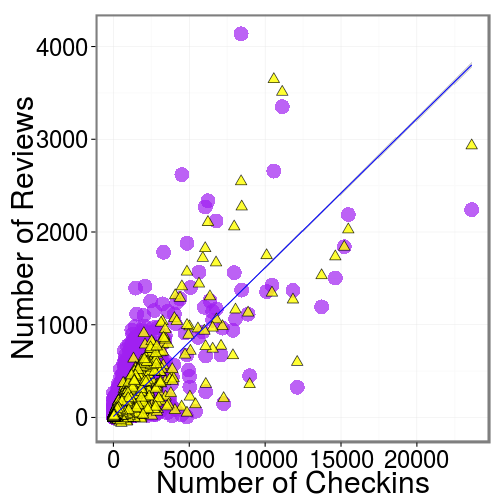

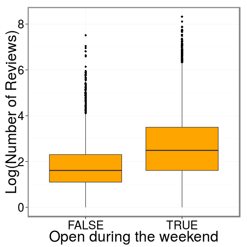

### Discussion: Ways to Increase Number of Reviews

- Number of reviews increases with checkins: \( reviews \approx 10 + 0.2\times checkins \)
- Our model explains increased review variance with increased checkins via coupling (*) terms
- Our linear model prediction algorithm explains 75% of the testing data
- Businesses open during the weekend receive more reviews (and better star ratings); wheelchair accessible also receive more reviews
- Star ratings and reviews/checkins depend on the business category; e.g., Health&Medical have better ratings than Financial Services